# L01 — Pre-processing: QC, doublets, normalization, HVGs

## Where this lecture fits

- Previous: Lec 00 — Tools and Foundational Concepts
- **You are here:** Lec 01 — *turning a raw count matrix into a clean, normalized object*
- Next: Lec 02 — Dim Reduction & Clustering
- **Companion tutorial:** Tutorial 01 — QC & Preprocessing
- **Companion book chapter:** Chapter 1: From Counts Matrix to Filtered Object

## Goals of this lecture

- See where pre-processing sits in the canonical pipeline
- Learn the three core QC metrics, **what they mean**, and **what counts as normal**
- Recognize and handle ambient-RNA contamination and droplet doublets
- Pick a normalization + feature-selection strategy that fits your data

**Note**

**Why this matters.**

- Every downstream geometric step (PCA, clustering, UMAP) treats the post-QC matrix as ground truth.
- Garbage in → confidently-wrong clusters out.
- There is no “fix the clustering” — you have to fix the QC.

### What is the same about scRNA-seq

- Same core measurement: **count of reads / UMIs per gene**
- Same statistical concerns: normalization, **batch effects**, multiple testing, replication
- Many downstream questions (DE, enrichment, co-expression) are the **same questions at a new resolution** — and reuse bulk tools (DESeq2, limma, WGCNA) after **pseudobulk aggregation** (Lecture 06)

### What is genuinely new about scRNA-seq

- **Sparsity**: ~90–95% zeros in typical droplet data — partly real biology, partly technical **dropout**
- **Cells are not replicates**: cells from one subject are not statistically independent — using `n = cells` is the most common mistake in the field
- **Cell type is a latent variable** you have to recover from the data
- **Integration** across samples is a first-class problem, not an afterthought

## Sparsity

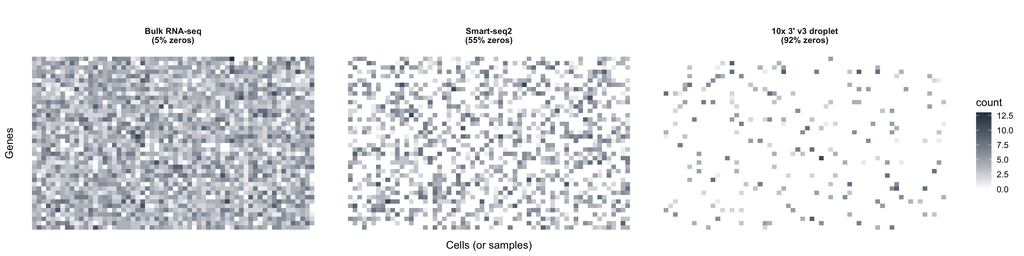

- **Bulk:** nearly every gene is detected in every sample (~5% zeros)
- **Smart-seq2**: ~50–60% zeros — moderate dropout but rich per-cell signal
- **10x 3’ v3** droplet: ~90–95% zeros — most (cell, gene) pairs are zero
- The implication for analysis: every step has to handle counts that are *mostly* zero.
- That’s why we have specialized normalisation (`SCTransform`), HVG selection, and graph-based clustering instead of the bulk RNA-seq toolkit.

## Bulk vs. single-cell — the tools

[figure not shown]

## Raw data processing (which we don’t do)

[figure not shown]

## Raw data processing (which we don’t do)

- Common tools:
  - **Cell Ranger** (10x, official)
  - **STARsolo** (STAR-based, fast, flexible)
  - **alevin-fry / salmon** (selective alignment, very fast)
  - **kb-python (kallisto | bustools)** (pseudoalignment)
- Final product: a **barcode(cell) × feature(gene) count matrix**
- We will start with the **count matrix**

## The downstream workflow at a glance

[figure not shown]

**Tip**

**A 4-step mental compression.** From here on out, every chunk of the pipeline (a) cleans something, (b) puts things on a sensible scale, (c) finds structure, (d) names that structure with biology.

## Generic scRNA-seq pipeline at a glance

[figure not shown]

## Specific Seurat workflow

[figure not shown]

# Quality control of the feature by barcode matrix

## Why Quality Control?

A droplet that “looks like a cell” in your matrix may actually be

- an empty droplet with ambient soup
- a dying cell leaking cytoplasm
- two (or more) cells in one droplet
- **a real cell**

QC is how we triage them.

## Why Quality Control?

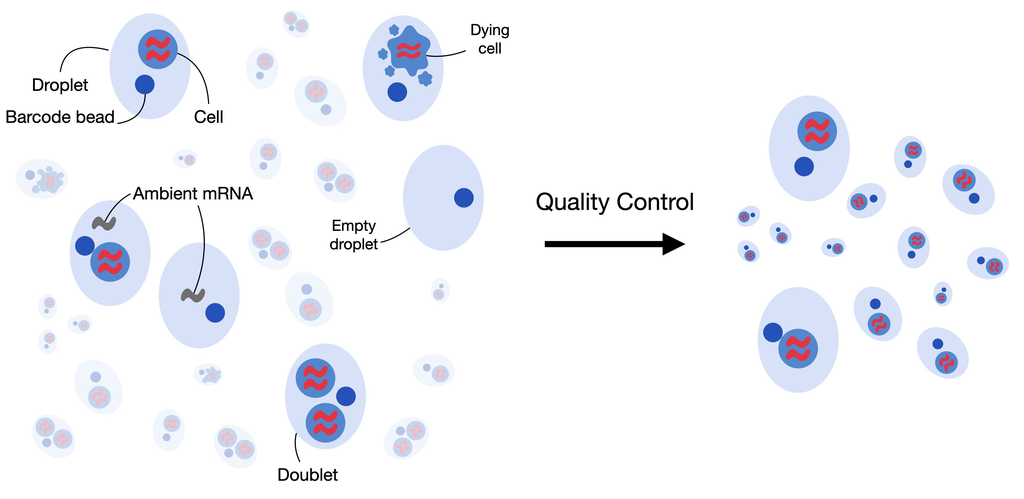

## Three core metrics

- `nFeature_RNA`: **genes detected per cell** — proxy for capture quality
- `nCount_RNA`: **total UMI counts per cell** — proxy for sequencing depth in that cell
- `percent.mt`: **% reads mapping to mitochondrial genes** — proxy for stress / dying cells (cytoplasmic mRNA leaks before mitochondrial mRNA)

[figure not shown]

## Normal ranges — a starting cheat sheet

**Note**

**Typical “healthy” thresholds for 10x 3’ v3 on dissociated tissue.** These are starting points, not rules — *always look at the distributions first.*

| Metric | Typical lower | Typical upper | Notes |
| --- | --- | --- | --- |
| `nFeature_RNA` (genes/cell) | 200–500 | 2,500–6,000 | Upper bound is dataset-specific; doublets push past it |
| `nCount_RNA` (UMIs/cell) | 500–1,000 | ~50,000 | Very high counts often = doublets, very low = empty |
| `percent.mt` | — | 5–10% (PBMC), 15–20% (tumor / fragile tissue) | Nuclei (snRNA) should be < ~1–2% |

**Warning**

**Watch-outs.**

- Brain / muscle / cardiomyocytes naturally have **high mitochondrial content** — a 5% threshold will throw away your biology.
- **snRNA-seq** should have almost no mitochondrial reads; if it does, your nuclei prep contaminated cytoplasm.
- A **bimodal `nCount_RNA`** distribution often means two cell sizes (e.g., lymphocytes + neutrophils), *not* doublets — don’t gate it away.

## What QC distributions actually look like

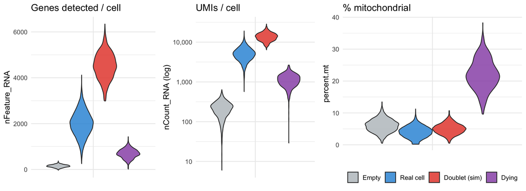

- Each violin shows what each “category” of barcode looks like in a typical 10x v3 dataset
- **Real cells** form the central bulk you want to keep;
  - **doublets** sit at the high end;
  - **dying** cells sit at the low-feature / high-mt corner;
  - **empty** droplets pile up at very low feature counts
- The correct cutoffs aren’t universal — they depend on your tissue and protocol

## Droplets can also be empty — or contaminated

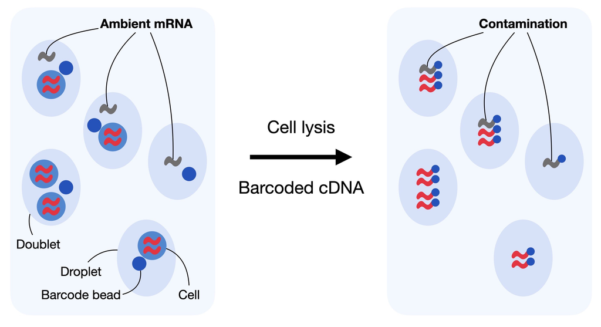

Ambient RNA — raster reference

- Many barcodes correspond to **empty droplets** with only ambient RNA — filter with `EmptyDrops` or the Cell Ranger knee-point
- Even real cells are contaminated by **ambient RNA soup**; estimate and subtract with `SoupX`, `DecontX`, or `CellBender`

# Doublet detection

## Doublets

- Droplets sometimes capture **two cells**
- Run doublet detection on each sample **before** integration
- Expected doublet rate scales with loading: ~0.8–1% per 1,000 cells loaded on 10x Chromium → ~8% at 10k cells, ~16% at 20k

## Doublets

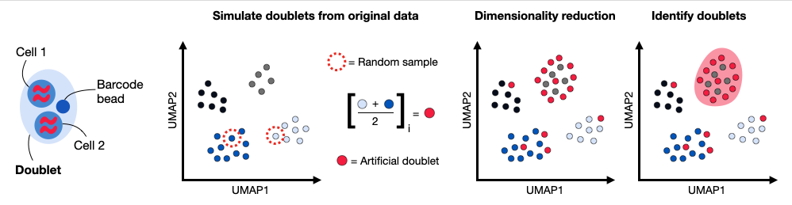

- **Simulate** artificial doublets by averaging random pairs of real cells
- Project real + simulated cells together in **reduced dimensions**
- Real cells that sit close to many simulated doublets are **flagged** as likely doublets

## Doublets

| Tool | Ecosystem | Notes |
| --- | --- | --- |
| `scDblFinder` | R / Bioc | Fast, recommended default |
| `DoubletFinder` | R | Needs pK sweep |
| `Scrublet` | Python | Classic choice in scanpy flows |

**Warning**

**Doublet detection runs *per sample*, not on a merged object.**

- Inter-sample mixtures are not doublets — they’re integration noise
- Pretending they are will silently drop real cells.

**Note**

**Seurat v5 note.**

- After `merge()` in Seurat v5, the RNA assay stores *split layers* (`counts.CTRL`, `counts.STIM`, …).
- Run `JoinLayers()` after merging the per-sample objects so that downstream steps see a single layer.
- The tutorial does this automatically after the doublet-detection merge.

## Doublet Score Distribution

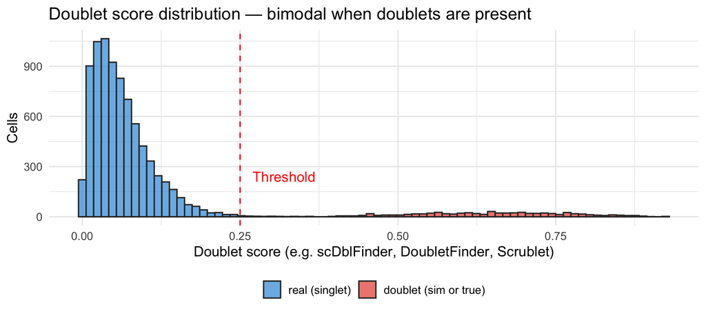

## Doublet Score Distribution

- Doublet detectors output a continuous **score** per cell — high = “looks like a simulated doublet”
- In a healthy run the distribution is **bimodal**: a tall left peak (real cells) and a small right shoulder (likely doublets)
- The threshold is set at the *expected doublet rate* implied by your loading concentration (e.g. 8% at 10k cells loaded on Chromium)
- If the distribution is **unimodal**, your sample either has no detectable doublets (rare in a 10k-cell run) or your simulator parameters need tuning

# Normalization

## Why normalize?

- Cells are sequenced to wildly different depths (factor-of-10 spread is common).
- Without correction, a “highly expressed” gene in a deeply sequenced cell looks the same as a moderately expressed one in a shallow cell.
- Normalization puts cells on a comparable scale before downstream math.

## Two dominant approaches

- **Log-normalization** (`NormalizeData` in Seurat) — fast, simple, the default in most tutorials
- **Variance-stabilizing** (`SCTransform` in Seurat) — models the negative-binomial mean–variance relationship; often better for low-count cells but slower

```r
# Seurat — log-normalization
seu <- NormalizeData(seu) |>
  FindVariableFeatures(nfeatures = 2000) |>
  ScaleData()

# Seurat — SCTransform (alternative, replaces the three calls above)
seu <- SCTransform(seu, verbose = FALSE)
```

**Tip**

**When to reach for SCTransform:** noisy or very low-depth data (~3,000 UMIs/cell median), or when you can see depth artefacts in your UMAP. For typical 10x v3 data, log-normalization is fine.

**Warning**

**Don’t normalize twice.** SCTransform replaces `NormalizeData` + `ScaleData`. Running both on the same object stacks transforms and breaks downstream assumptions.

## Log-norm vs SCTransform

[figure not shown]

.

- Log-normalization removes depth but leaves a mean–variance trend for medium/high-expression genes
- SCTransform’s regularized NB-GLM residuals stay flat across expression levels

# Feature selection (HVGs)

## Why Highly Variable Genes (HVGs)?

- Use the ~1,000–3,000 most variable genes for downstream geometry
- Dramatically reduces noise from ubiquitously-expressed housekeeping genes
- Functions
  - Seurat: `FindVariableFeatures()`
  - scanpy: `sc.pp.highly_variable_genes()`

**Note**

**Typical settings:** `nfeatures = 2000` is the Seurat default and a defensible choice for most datasets. Bump to 3,000–5,000 for atlas-scale or highly heterogeneous data; drop to 1,000 only if your dataset is small and unimodal.

**Warning**

**Pitfalls in HVG selection.** - Including **mitochondrial / ribosomal genes** as HVGs lets technical variation drive your PCs — Many pipelines exclude these patterns by default. - If you regress out cell-cycle scores, do it *before* HVG selection, otherwise cycling genes dominate the variable list.

## What the HVG (variable feature) plot shows

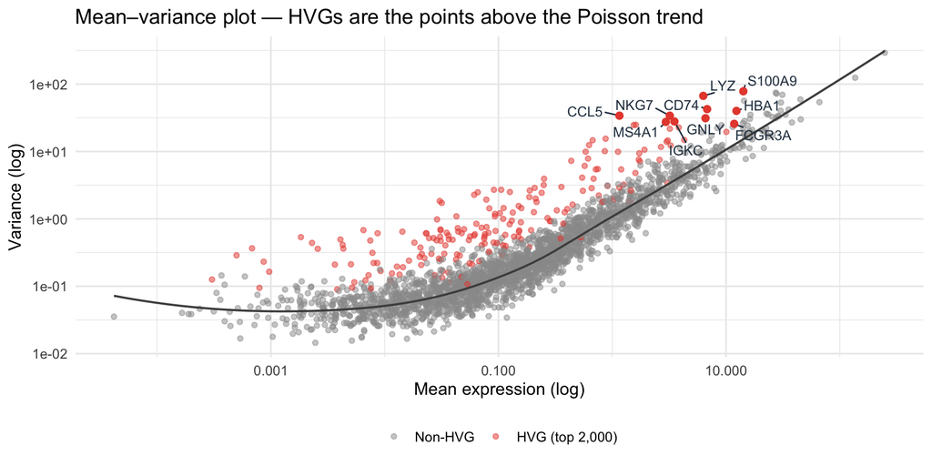

## What the HVG (variable feature) plot shows

- Every gene gets a (mean, variance) pair. The **grey curve** is the expected mean–variance relationship for technical / housekeeping genes (roughly Poisson with overdispersion).
- Genes that sit **well above the trend** are over-dispersed — their variance can’t be explained by sampling noise alone, so they’re carrying biological signal. Those are your HVGs.
- `FindVariableFeatures(seu, selection.method = "vst", nfeatures = 2000)` returns the top 2,000 such genes, ranked by *standardized residual variance*. `VariableFeaturePlot()` is exactly this picture.
- Marker labels in the corner are the exact reason you do this: in a PBMC run the top HVGs include the genes you’d already expect (`LYZ`, `S100A9`, `CD74`, `MS4A1`, …) — you should recognise them.

# Let’s Get Started

## The `ifnb` dataset

- The workshop dataset — the Kang *et al.* PBMCs we call “`ifnb`”
- Single-cell RNA-seq data of human peripheral blood mononuclear cells (PBMCs).
- Two conditions: resting (CONTROL) and interferon-beta (IFN-β) stimulated (STIM) cells
- Loaded via `muscData::Kang18_8vs8()`
- Starts at **~24,500 annotated singlets** across CTRL and STIM.
- After the QC filters in Tutorial 01 you should retain **~23,000 cells**.

**Tip**

**Doublet detection in this tutorial runs *per sample* (CTRL then STIM separately)** with `scDblFinder`.

- The two per-sample objects are then merged back with `merge()` and `JoinLayers()` before the final filter.
- Running doublet detection on the merged object would treat cross-sample cell pairs as doublets — they are not.

## NOTE — `percent.rb` and when to use it

Tutorial 01 also computes `percent.rb` (ribosomal-protein fraction). It is **not** a standard QC filter; rather:

- A very high `percent.rb` (>50%) in a cluster often signals a *metabolically active* or *activated* state, not a low-quality cell.
- Monitor it per sample: if one sample has dramatically higher `percent.rb`, check whether library prep differed.
- Do **not** filter on `percent.rb` by default — just note it.